# Coursework Report

*N* removed NAs: 3

*N* removed typo: 1

*N* removed <18: 23

*N* total clean: 123

| Group | *N* | *M*<sub>age</sub> | *M*<sub>rating</sub> |
| --- | --- | --- | --- |
| Control | 63 | 21.22 | 6.40 |
| Experim | 60 | 20.72 | 5.85 |

**Main analysis results**

*t*(121) = 4.26, *p* < .001

[interactive chart not shown]

[figure not shown]

[interactive chart not shown]

# Coursework Report

Analysing Data, Spring 2020

# Methods

## Design

*Table 1* Descriptive statistics by Age

[output not shown]

# Results

We investigated whether the participants who viewed the picture with the red background would rate the man as more attractive than those who viewed the picture with the white background. Firstly, a composite score of the individual scores given was created for each participant in both groups. This was achieved by creating a mean score of the ratings given by the participants for each of the three questions.

The outcome of this study showed that those who viewed the picture of the man in the white condition actually rated the man as more attractive (*M* = 6.38, *SD* = 0.67) than the participants that viewed the picture in the red condition (*M* = 5.85, *SD* = 0.76).

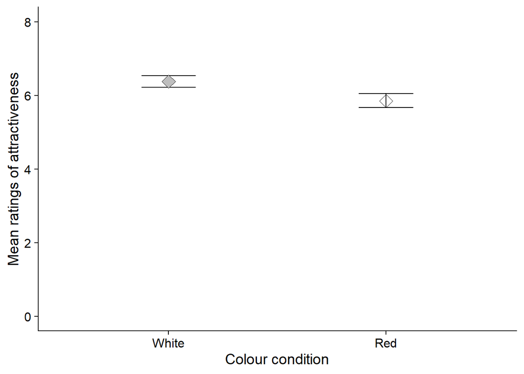

# Discussion

The results of this study do not support the original hypothesis, as the participants that viewed the picture with the red background did not give a higher mean attractiveness rating than those that viewed the picture of the man with the white background. This outcome contradict the results of the original study by Elliot et al (2010) and shows that the colour red may not increase the perceived attractiveness of a person. Further replications give weight to this idea, for example, that of Hesslinger et al (2015). This study used 89 participants both male (*n* = 17) and female (*n* = 72). They found the difference between attractiveness ratings between the two colour conditions was insignificant, thus concluding that colour had no effect on attractiveness ratings (Hesslinger, Goldbach & Carbon, 2015).

This fluctuation in results is interesting; there are a couple of reasons as to why these results differ. Firstly, there is speculation over the idea that the original studies by Elliot et al may have been subject to publication bias and the results may have consisted of Type 1 errors (Francis, 2013).  
Francis claims that the design of the experiment may in itself have led to publication bias; for example, the use of multiple measures in a study, such as that of experiment 7 (Francis, 2013). This sometimes allows for the experimenters to carefully select the measures that reject the null hypothesis and discard of the ones that don’t. Additionally, Francis stated that the multiple experiments conducted by Elliot et al may have been a repetition of the same experiment, which were repeated many times until the null hypothesis was rejected (Francis, 2013). This publication bias may be the reason for the deviation in results in the replications. As the original results may have not been reliable in the first place.

Furthermore, a weakness of this study was the range of ages, which was 18 - 25 years. This means that the results are only applicable to women of that age group. To understand the effect of colour on perceived attractiveness to it’s full extent, future research will have to increase the range of ages, so that the full picture can be understood. This area of research is complex and still requires further investigation to fully understand if and why the colour red increases attractiveness. For example, the colour red and its association with testosterone, which can be seen in nature, such as with Stickleback fish (Elliot et al, 2010). Research shows that women are often more attracted to men with greater testosterone (Elliot et al, 2010). Future research should look into whether this association between testosterone, the colour red and perceived attractiveness can be seen in humans.

To conclude, the results of this study deviate from the original findings, as do the results of other replications. It is suggested that the original study may have been subject to publication bias, which would make the results invalid. Regardless of this, further research is required to fully understand whether there is a link between the colour red and perceived attractiveness.

# References

1. Elliot, A., Niesta Kayser, D., Greitemeyer, T., Lichtenfeld, S., Gramzow, R., Maier, M., & Liu, H. (2010). Red, rank, and romance in women viewing men. Journal Of Experimental Psychology: General, 139(3), 399-417. doi: 10.1037/a0019689
2. Francis, G. (2013). Publication bias in “Red, rank, and romance in women viewing men,” by Elliot et al. (2010). Journal Of Experimental Psychology: General, 142(1), 292-296. doi: 10.1037/a0027923
3. Hackshaw, A. (2008). Small studies: strengths and limitations. European Respiratory Journal, 32(5), 1141-1143. doi: 10.1183/09031936.00136408
4. Hesslinger, V., Goldbach, L., & Carbon, C. (2015). Men in red: A reexamination of the red-attractiveness effect. Psychonomic Bulletin & Review, 22(4), 1142-1148. doi: 10.3758/s13423-015-0866-8